# Water table EDA 2

Your goal is to predict the operating condition of a waterpoint for each record in the dataset. You are provided the following set of information about the waterpoints:

- `amount_tsh` - Total static head (amount water available to waterpoint)
- `date_recorded` - The date the row was entered
- `funder` - Who funded the well
- `gps_height` - Altitude of the well
- `installer` - Organization that installed the well
- `longitude` - GPS coordinate
- `latitude` - GPS coordinate
- `wpt_name` - Name of the waterpoint if there is one
- `num_private` -
- `basin` - Geographic water basin
- `subvillage` - Geographic location
- `region` - Geographic location
- `region_code` - Geographic location (coded)
- `district_code` - Geographic location (coded)
- `lga` - Geographic location
- `ward` - Geographic location
- `population` - Population around the well
- `public_meeting` - True/False
- `recorded_by` - Group entering this row of data
- `scheme_management` - Who operates the waterpoint
- `scheme_name` - Who operates the waterpoint
- `permit` - If the waterpoint is permitted
- `construction_year` - Year the waterpoint was constructed
- `extraction_type` - The kind of extraction the waterpoint uses
- `extraction_type_group` - The kind of extraction the waterpoint uses
- `extraction_type_class` - The kind of extraction the waterpoint uses
- `management` - How the waterpoint is managed
- `management_group` - How the waterpoint is managed
- `payment` - What the water costs
- `payment_type` - What the water costs
- `water_quality` - The quality of the water
- `quality_group` - The quality of the water
- `quantity` - The quantity of water
- `quantity_group` - The quantity of water
- `source` - The source of the water
- `source_type` - The source of the water
- `source_class` - The source of the water
- `waterpoint_type` - The kind of waterpoint
- `waterpoint_type_group` - The kind of waterpoint

### Feature data example

For example, a single row in the dataset might have these values:

| amount_tsh | 300.0 |
| --- | --- |
| date_recorded | 2013-02-26 |
| funder | Germany Republi |
| gps_height | 1335 |
| installer | CES |
| longitude | 37.2029845 |
| latitude | -3.22870286 |
| wpt_name | Kwaa Hassan Ismail |
| num_private | 0 |
| basin | Pangani |
| subvillage | Bwani |
| region | Kilimanjaro |
| region_code | 3 |
| district_code | 5 |
| lga | Hai |
| ward | Machame Uroki |
| population | 25 |
| public_meeting | True |
| recorded_by | GeoData Consultants Ltd |
| scheme_management | Water Board |
| scheme_name | Uroki-Bomang'ombe water sup |
| permit | True |
| construction_year | 1995 |
| extraction_type | gravity |
| extraction_type_group | gravity |
| extraction_type_class | gravity |
| management | water board |
| management_group | user-group |
| payment | other |
| payment_type | other |
| water_quality | soft |
| quality_group | good |
| quantity | enough |
| quantity_group | enough |
| source | spring |
| source_type | spring |
| source_class | groundwater |
| waterpoint_type | communal standpipe |
| waterpoint_type_group | communal standpipe |

## The labels in this dataset

The labels in this dataset are simple. There are three possible values:

- `functional` - the waterpoint is operational and there are no repairs needed
- `functional needs repair` - the waterpoint is operational, but needs repairs
- `non functional` - the waterpoint is not operational

```python
import pandas as pd
%matplotlib inline
```

```python
train=pd.read_csv("train.csv",index_col='id',infer_datetime_format=True,parse_dates=True)
labels=pd.read_csv("labels.csv",index_col='id')
```

```python
train=train.join(labels)
```

```python
train.info()
```

```
<class 'pandas.core.frame.DataFrame'>
Int64Index: 59400 entries, 69572 to 26348
Data columns (total 40 columns):
amount_tsh               59400 non-null float64
date_recorded            59400 non-null object
funder                   55765 non-null object
gps_height               59400 non-null int64
installer                55745 non-null object
longitude                59400 non-null float64
latitude                 59400 non-null float64
wpt_name                 59400 non-null object
num_private              59400 non-null int64
basin                    59400 non-null object
subvillage               59029 non-null object
region                   59400 non-null object
region_code              59400 non-null int64
district_code            59400 non-null int64
lga                      59400 non-null object
ward                     59400 non-null object
population               59400 non-null int64
public_meeting           56066 non-null object
recorded_by              59400 non-null object
scheme_management        55523 non-null object
scheme_name              31234 non-null object
permit                   56344 non-null object
construction_year        59400 non-null int64
extraction_type          59400 non-null object
extraction_type_group    59400 non-null object
extraction_type_class    59400 non-null object
management               59400 non-null object
management_group         59400 non-null object
payment                  59400 non-null object
payment_type             59400 non-null object
water_quality            59400 non-null object
quality_group            59400 non-null object
quantity                 59400 non-null object
quantity_group           59400 non-null object
source                   59400 non-null object
source_type              59400 non-null object
source_class             59400 non-null object
waterpoint_type          59400 non-null object
waterpoint_type_group    59400 non-null object
status_group             59400 non-null object
dtypes: float64(3), int64(6), object(31)
memory usage: 21.1+ MB
```

# To get some info about numerical columns we use describe

```python
train.describe()
```

|  | amount_tsh | gps_height | longitude | latitude | num_private | region_code | district_code | population | construction_year |
| --- | --- | --- | --- | --- | --- | --- | --- | --- | --- |
| count | 59400.000000 | 59400.000000 | 59400.000000 | 5.940000e+04 | 59400.000000 | 59400.000000 | 59400.000000 | 59400.000000 | 59400.000000 |
| mean | 317.650385 | 668.297239 | 34.077427 | -5.706033e+00 | 0.474141 | 15.297003 | 5.629747 | 179.909983 | 1300.652475 |
| std | 2997.574558 | 693.116350 | 6.567432 | 2.946019e+00 | 12.236230 | 17.587406 | 9.633649 | 471.482176 | 951.620547 |
| min | 0.000000 | -90.000000 | 0.000000 | -1.164944e+01 | 0.000000 | 1.000000 | 0.000000 | 0.000000 | 0.000000 |
| 25% | 0.000000 | 0.000000 | 33.090347 | -8.540621e+00 | 0.000000 | 5.000000 | 2.000000 | 0.000000 | 0.000000 |
| 50% | 0.000000 | 369.000000 | 34.908743 | -5.021597e+00 | 0.000000 | 12.000000 | 3.000000 | 25.000000 | 1986.000000 |
| 75% | 20.000000 | 1319.250000 | 37.178387 | -3.326156e+00 | 0.000000 | 17.000000 | 5.000000 | 215.000000 | 2004.000000 |
| max | 350000.000000 | 2770.000000 | 40.345193 | -2.000000e-08 | 1776.000000 | 99.000000 | 80.000000 | 30500.000000 | 2013.000000 |

# get counts of output variable i.e Status group

```python
print(train.status_group.value_counts())
print(train.status_group.value_counts(normalize=True))
```

```
functional                 32259
non functional             22824
functional needs repair     4317
Name: status_group, dtype: int64
functional                 0.543081
non functional             0.384242
functional needs repair    0.072677
Name: status_group, dtype: float64
```

# Plot a simple bar graph using pandas plot function

# Univariate Analysis

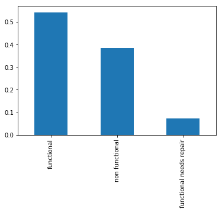

```python
train.status_group.value_counts(normalize=True).plot(kind='bar')
```

```python
numeric_columns=list(train.select_dtypes(exclude=[object]).columns)
categorical_columns=list(train.select_dtypes(include=[object]).columns)
print (numeric_columns)
print (categorical_columns)
print (len(numeric_columns))
print (len(categorical_columns))
```

```
['amount_tsh', 'gps_height', 'longitude', 'latitude', 'num_private', 'region_code', 'district_code', 'population', 'construction_year']
['date_recorded', 'funder', 'installer', 'wpt_name', 'basin', 'subvillage', 'region', 'lga', 'ward', 'public_meeting', 'recorded_by', 'scheme_management', 'scheme_name', 'permit', 'extraction_type', 'extraction_type_group', 'extraction_type_class', 'management', 'management_group', 'payment', 'payme…
9
31
```

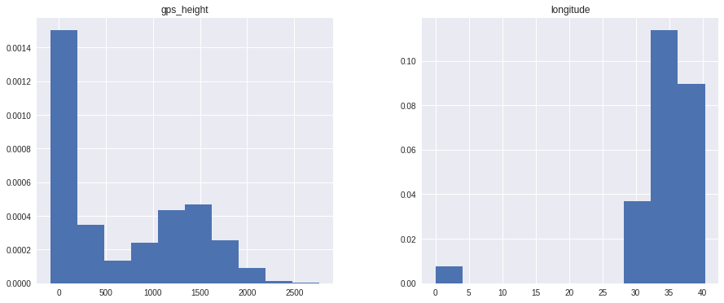

```python
# small_categorical_columns=[]
# for col in categorical_columns:
#     print(train[col].value_counts().size)
#     if train[col].value_counts().size<=21:
#         small_categorical_columns.append(col)
# print (small_categorical_columns)
# print (len(small_categorical_columns))

train[numeric_columns[1:3]].hist(figsize=(15, 6),normed=1);
```

```python
train.population.value_counts()
```

```
0       21381
1        7025
200      1940
150      1892
250      1681
300      1476
100      1146
50       1139
500      1009
350       986
120       916
400       775
60        706
30        626
40        552
```

[output cut: 47 more lines]

[output not shown]

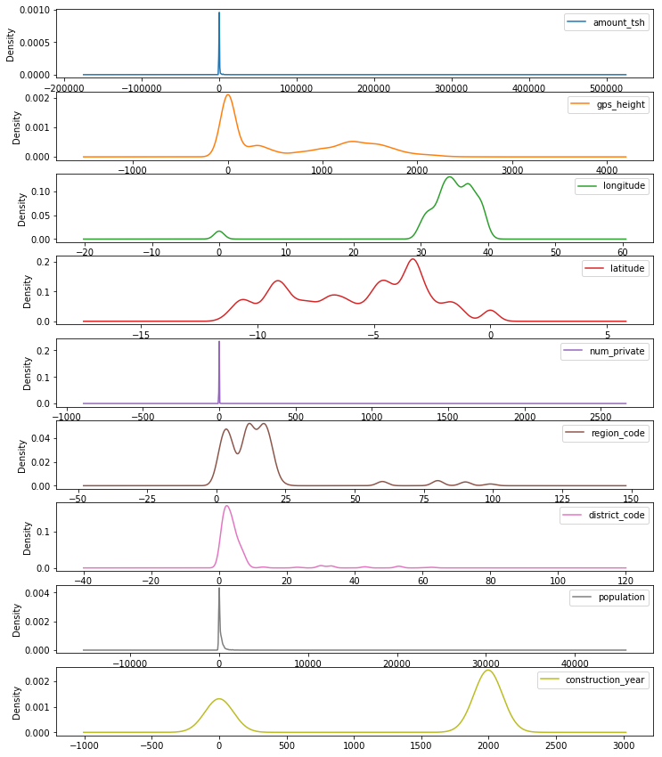

```python
train[numeric_columns].plot(kind='density', subplots=True,
                  layout=(9, 1), sharex=False, figsize=(12, 15))
```

```python
# some are categorical in disguise need to remove them form here
```

```python
import matplotlib.pyplot as plt
# pip install seaborn
import seaborn as sns
plt.rcParams['figure.figsize'] = (15, 20)
# sns.countplot(x='International plan', hue='Churn', data=df);
```

```
1
2
3
4
5
6
7
8
9
```

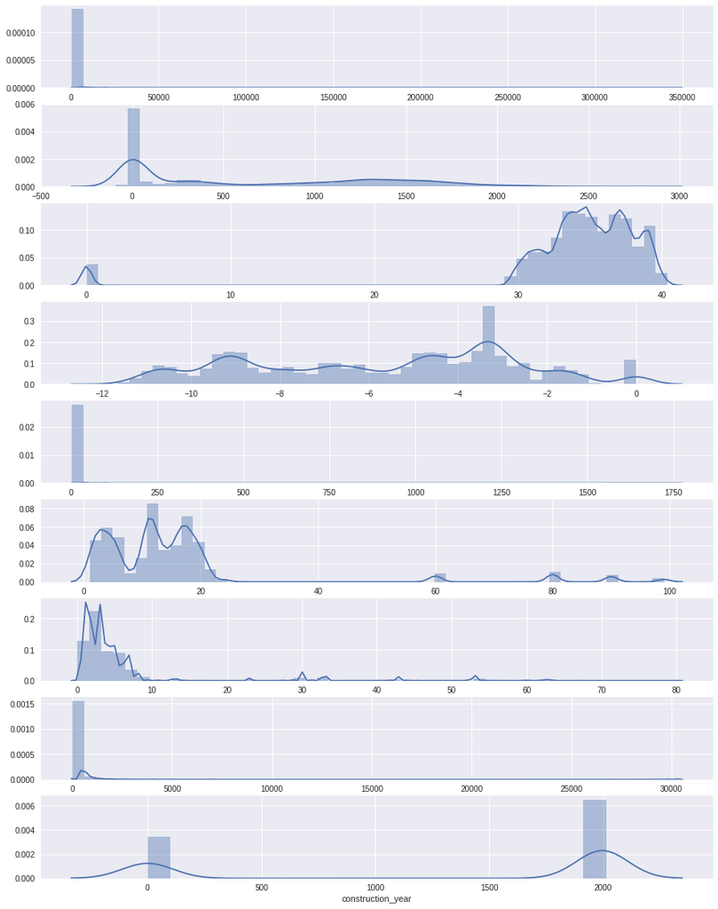

```python
fig,axes=plt.subplots(nrows=len(numeric_columns),ncols=1)
count=0

for col in numeric_columns:
    sns.distplot(train[col],ax=axes[count]);
    count+=1
    print (count)
```

```
1
2
3
4
5
6
7
8
9
```

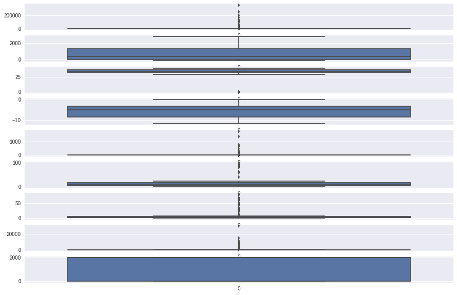

```python
fig,axes=plt.subplots(nrows=len(numeric_columns),ncols=1)

count=0
for col in numeric_columns:
    sns.boxplot(data=train[col],ax=axes[count]);
    count+=1
    print (count)
```